# Chapter 15 - Various lexical measures

Bodo Winter

8/26/2018

## Introduction

This is the analysis for Chapter 15, which serves two purposes. First, the senses are correlated with all kinds of linguistic variables, including frequency, semantic complexity and iconicity. This serves to show that knowing about a word’s sensory modality is predictive of linguistic behavior in interesting ways. The second goal is to compare different ways of operationalizing the senses with each other, namely, the continuous modality norms, the dominant modality norms, and the cluster model. This allows investigating the extent to which the five senses folk model is a useful model for linguistic data.

We begin by loading in the data and libraries.

```r
## Libraries:

library(png)        # for plotting sensory modality images
library(car)
library(MASS)
library(tidyverse)
library(stringr)

## Load data:

lyn <- read_csv('../processed-data/lyn_cluster.csv')
SUBTL <- read_csv('../raw-data/frequency_SUBTLEX_POS.csv')
icon <- read_csv('../raw-data/iconicity_ratings.csv')
wn <- read_csv('../raw-data/wordnet_sense_count_adjective.csv')
oed <- read_csv('../raw-data/adjectives_OED_etymologies.csv')

## Load plotting functions:

source('../functions/boxplot_fnc.R')
```

This time, we will use the image data (from freepix.com). So let’s load in images and specify the color values.

```r
## Load in images:

s1 <- readPNG('../figures/sight.png')
s2 <- readPNG('../figures/touch.png')
s3 <- readPNG('../figures/sound.png')
s4 <- readPNG('../figures/taste.png')
s5 <- readPNG('../figures/smell.png')

## Define vector of names:

sense_names <- str_c('s', 1:5)

## Define colors:

mycols <- c('#f37058', '#f79038', '#efbe1b',
            '#425fac', '#30b77d')
```

## Preprocessing different datasets

Compute log-transformed frequencies from SUBTLEX.

```r
SUBTL <- SUBTL %>%
  rename(Freq = FREQcount,
         POS = Dom_PoS_SUBTLEX) %>%
  mutate(LogFreq = log10(Freq + 1))
```

Merge everything:

```r
## Iconicity data:

lyn <- left_join(lyn,
                 icon, by = c('Word' = 'Word'))

## Frequency data:

lyn <- left_join(lyn,
                 select(SUBTL, POS, Word, Freq, LogFreq),
                 by = c('Word' = 'Word'))

## Add senses from WordNet:

lyn <- left_join(lyn, wn, by = c('Word' = 'Word')) %>%
    mutate(LogSense = log10(Sense_count + 1))
```

Check overlap between the different datasets:

```r
## SUBTLEX:

sum(!is.na(lyn$LogFreq))
```

```
## [1] 413
```

```r
sum(!is.na(lyn$LogFreq)) / nrow(lyn)
```

```
## [1] 0.9763593
```

```r
## WordNet:

sum(!is.na(lyn$Sense_count))
```

```
## [1] 370
```

```r
sum(!is.na(lyn$Sense_count)) / nrow(lyn)
```

```
## [1] 0.8747045
```

```r
## Iconicity:

sum(!is.na(lyn$Iconicity))
```

```
## [1] 422
```

```r
sum(!is.na(lyn$Iconicity)) / nrow(lyn)
```

```
## [1] 0.9976359
```

## Setup for plotting

First, we get ordered clusters, in order of sense, then frequency:

```r
class_order <- lyn %>% group_by(Class, Image) %>%
  summarize(LogFreq = mean(LogFreq, na.rm = TRUE)) %>%
    arrange(Image, desc(LogFreq)) %>% pull(Class)

image_order <- lyn %>% group_by(Class, Image) %>%
    summarize(LogFreq = mean(LogFreq, na.rm = TRUE)) %>%
    arrange(Image, desc(LogFreq)) %>% pull(Image)

color_order <- mycols[as.numeric(as.factor(image_order))]
```

Then we put in the labels into the main data frame:

```r
lyn <- mutate(lyn,
              Clust = factor(Class, levels = class_order))
```

Next, the plotting parameters:

```r
x_fac <- 0.15
x_fac_img <- 0.3
y_fac_img <- 0.036
```

## All boxplots

This will plot all boxplots:

```r
boxplot_fnc(lyn, 'LogFreq',
            ylims = c(0, 5),
            ylab = 'Log10 Frequency',
            which_x = 0, y_axis = seq(0, 5, 1),
            hlty = 1)
boxplot_fnc(lyn, 'LogSense',
            ylims = c(0, 2),
            ylab = 'Log10 Sense Count',
            which_x = 0, y_axis = seq(0, 2, 0.5),
            hlty = 1)
boxplot_fnc(lyn,
            'Iconicity', ylims = c(-2, 5),
            ylab = 'Iconicity',
            which_x = 0, y_axis = seq(-2, 5, 1),
            hlty = 2)
```

[output not shown]

## Frequency models

For each of the linguistic measures, we now compare a model with the clusters, with the dominant modality classifications, and with the continuous measures.

```r
## Clusters:

summary(freq.class <- lm(LogFreq ~ Class, lyn))
```

```
##
## Call:
## lm(formula = LogFreq ~ Class, data = lyn)
##
## Residuals:
##     Min      1Q  Median      3Q     Max
## -1.8776 -0.6749 -0.1139  0.6396  2.6122
##
## Coefficients:
##                         Estimate Std. Error t value Pr(>|t|)
## (Intercept)              1.33733    0.19966   6.698 7.17e-11 ***
## Classgross surface       0.71604    0.23657   3.027 0.002631 **
## Classimpression-related  0.90272    0.26217   3.443 0.000635 ***
## Classmotion & touch      0.68527    0.24657   2.779 0.005705 **
## Classmultimodal          0.84127    0.22692   3.707 0.000239 ***
## Classpure sight          1.04359    0.24553   4.250 2.66e-05 ***
## Classshape & extent      0.91833    0.24765   3.708 0.000238 ***
## Classskin & temperature  1.13206    0.30932   3.660 0.000286 ***
## Classsmell               0.06054    0.35154   0.172 0.863357
## Classsound 1             0.78024    0.25696   3.036 0.002550 **
## Classsound 2             0.51369    0.25696   1.999 0.046271 *
## Classtaste               0.37887    0.26033   1.455 0.146353
## ---
## Signif. codes:  0 '***' 0.001 '**' 0.01 '*' 0.05 '.' 0.1 ' ' 1
##
## Residual standard error: 0.915 on 401 degrees of freedom
##   (10 observations deleted due to missingness)
## Multiple R-squared:  0.08362,    Adjusted R-squared:  0.05848
## F-statistic: 3.326 on 11 and 401 DF,  p-value: 0.0002124
```

```r
anova(freq.class)
```

```
## Analysis of Variance Table
##
## Response: LogFreq
##            Df Sum Sq Mean Sq F value    Pr(>F)
## Class      11  30.63 2.78483  3.3264 0.0002124 ***
## Residuals 401 335.71 0.83718
## ---
## Signif. codes:  0 '***' 0.001 '**' 0.01 '*' 0.05 '.' 0.1 ' ' 1
```

```r
## Dominant modality:

summary(freq.mod <- lm(LogFreq ~ DominantModality, lyn))
```

```
##
## Call:
## lm(formula = LogFreq ~ DominantModality, data = lyn)
##
## Residuals:
##      Min       1Q   Median       3Q      Max
## -1.94821 -0.66945 -0.09072  0.63739  2.61863
##
## Coefficients:
##                           Estimate Std. Error t value Pr(>|t|)
## (Intercept)                 1.9478     0.1111  17.533   <2e-16 ***
## DominantModalityGustatory  -0.3708     0.1738  -2.134   0.0335 *
## DominantModalityHaptic      0.1682     0.1565   1.075   0.2832
## DominantModalityOlfactory  -0.3228     0.2175  -1.484   0.1386
## DominantModalityVisual      0.3014     0.1282   2.351   0.0192 *
## ---
## Signif. codes:  0 '***' 0.001 '**' 0.01 '*' 0.05 '.' 0.1 ' ' 1
##
## Residual standard error: 0.9161 on 408 degrees of freedom
##   (10 observations deleted due to missingness)
## Multiple R-squared:  0.06526,    Adjusted R-squared:  0.0561
## F-statistic: 7.122 on 4 and 408 DF,  p-value: 1.501e-05
```

```r
anova(freq.mod)
```

```
## Analysis of Variance Table
##
## Response: LogFreq
##                   Df Sum Sq Mean Sq F value    Pr(>F)
## DominantModality   4  23.91  5.9772  7.1217 1.501e-05 ***
## Residuals        408 342.43  0.8393
## ---
## Signif. codes:  0 '***' 0.001 '**' 0.01 '*' 0.05 '.' 0.1 ' ' 1
```

```r
aggregate(LogFreq ~ DominantModality, lyn, mean) %>%
  mutate(LogFreq = round(LogFreq, 1))
```

```
##   DominantModality LogFreq
## 1         Auditory     1.9
## 2        Gustatory     1.6
## 3           Haptic     2.1
## 4        Olfactory     1.6
## 5           Visual     2.2
```

```r
## Raw counts:

aggregate(Freq ~ DominantModality, lyn, mean) %>%
  mutate(Freq = round(Freq, 0))
```

```
##   DominantModality Freq
## 1         Auditory  347
## 2        Gustatory  267
## 3           Haptic 1036
## 4        Olfactory  248
## 5           Visual 2018
```

```r
## Continuous predictor:

summary(freq.cont <- lm(LogFreq ~ VisualStrengthMean +
                          GustatoryStrengthMean +
                          OlfactoryStrengthMean +
                          HapticStrengthMean +
                          AuditoryStrengthMean, lyn))
```

```
##
## Call:
## lm(formula = LogFreq ~ VisualStrengthMean + GustatoryStrengthMean +
##     OlfactoryStrengthMean + HapticStrengthMean + AuditoryStrengthMean,
##     data = lyn)
##
## Residuals:
##     Min      1Q  Median      3Q     Max
## -2.1192 -0.6303 -0.1214  0.5906  2.6160
##
## Coefficients:
##                       Estimate Std. Error t value Pr(>|t|)
## (Intercept)            0.63101    0.22802   2.767  0.00591 **
## VisualStrengthMean     0.32050    0.04615   6.945 1.51e-11 ***
## GustatoryStrengthMean  0.04862    0.04631   1.050  0.29444
## OlfactoryStrengthMean -0.02644    0.05083  -0.520  0.60319
## HapticStrengthMean     0.02111    0.03063   0.689  0.49099
## AuditoryStrengthMean   0.13698    0.03427   3.997 7.62e-05 ***
## ---
## Signif. codes:  0 '***' 0.001 '**' 0.01 '*' 0.05 '.' 0.1 ' ' 1
##
## Residual standard error: 0.8798 on 407 degrees of freedom
##   (10 observations deleted due to missingness)
## Multiple R-squared:   0.14,  Adjusted R-squared:  0.1295
## F-statistic: 13.26 on 5 and 407 DF,  p-value: 5.591e-12
```

```r
summary(freq.cont2 <- lm(LogFreq ~ 1, lyn))
```

```
##
## Call:
## lm(formula = LogFreq ~ 1, data = lyn)
##
## Residuals:
##     Min      1Q  Median      3Q     Max
## -1.7635 -0.6666 -0.1251  0.5759  2.8033
##
## Coefficients:
##             Estimate Std. Error t value Pr(>|t|)
## (Intercept)   2.0646     0.0464   44.49   <2e-16 ***
## ---
## Signif. codes:  0 '***' 0.001 '**' 0.01 '*' 0.05 '.' 0.1 ' ' 1
##
## Residual standard error: 0.943 on 412 degrees of freedom
##   (10 observations deleted due to missingness)
```

```r
## Overall effect:

anova(freq.cont)
```

```
## Analysis of Variance Table
##
## Response: LogFreq
##                        Df  Sum Sq Mean Sq F value    Pr(>F)
## VisualStrengthMean      1  35.752  35.752 46.1885 3.833e-11 ***
## GustatoryStrengthMean   1   1.027   1.027  1.3274   0.24995
## OlfactoryStrengthMean   1   2.143   2.143  2.7691   0.09687 .
## HapticStrengthMean      1   0.018   0.018  0.0227   0.88028
## AuditoryStrengthMean    1  12.365  12.365 15.9749 7.621e-05 ***
## Residuals             407 315.036   0.774
## ---
## Signif. codes:  0 '***' 0.001 '**' 0.01 '*' 0.05 '.' 0.1 ' ' 1
```

```r
anova(freq.cont2, freq.cont, test = 'F')
```

```
## Analysis of Variance Table
##
## Model 1: LogFreq ~ 1
## Model 2: LogFreq ~ VisualStrengthMean + GustatoryStrengthMean + OlfactoryStrengthMean +
##     HapticStrengthMean + AuditoryStrengthMean
##   Res.Df    RSS Df Sum of Sq      F    Pr(>F)
## 1    412 366.34
## 2    407 315.04  5    51.306 13.257 5.591e-12 ***
## ---
## Signif. codes:  0 '***' 0.001 '**' 0.01 '*' 0.05 '.' 0.1 ' ' 1
```

```r
## Variance inflation factors:

vif(freq.cont)
```

```
##    VisualStrengthMean GustatoryStrengthMean OlfactoryStrengthMean
##              1.511729              2.701051              2.922570
##    HapticStrengthMean  AuditoryStrengthMean
##              1.284384              1.610425
```

```r
## BIC and evidence ratios:

BIC(freq.class);BIC(freq.mod);BIC(freq.cont)
```

```
## [1] 1164.772
```

```
## [1] 1130.799
```

```
## [1] 1102.383
```

## Semantic complexity models

Next, we repeat these analyses for semantic complexity.

```r
## Cluster model, includes frequency:

summary(sem.class <- lm(LogSense ~ Class + LogFreq, lyn))
```

```
##
## Call:
## lm(formula = LogSense ~ Class + LogFreq, data = lyn)
##
## Residuals:
##      Min       1Q   Median       3Q      Max
## -0.58837 -0.13042 -0.00594  0.12904  0.55958
##
## Coefficients:
##                          Estimate Std. Error t value Pr(>|t|)
## (Intercept)              0.253371   0.044951   5.637 3.55e-08 ***
## Classgross surface       0.006824   0.051369   0.133 0.894392
## Classimpression-related -0.166586   0.058031  -2.871 0.004343 **
## Classmotion & touch     -0.089430   0.053257  -1.679 0.093993 .
## Classmultimodal         -0.068212   0.049521  -1.377 0.169246
## Classpure sight         -0.149174   0.053754  -2.775 0.005811 **
## Classshape & extent     -0.087312   0.054290  -1.608 0.108673
## Classskin & temperature -0.025448   0.068451  -0.372 0.710286
## Classsmell              -0.070090   0.077584  -0.903 0.366925
## Classsound 1            -0.220875   0.064209  -3.440 0.000651 ***
## Classsound 2            -0.246571   0.059060  -4.175 3.76e-05 ***
## Classtaste              -0.121205   0.058561  -2.070 0.039204 *
## LogFreq                  0.185477   0.010976  16.898  < 2e-16 ***
## ---
## Signif. codes:  0 '***' 0.001 '**' 0.01 '*' 0.05 '.' 0.1 ' ' 1
##
## Residual standard error: 0.1947 on 354 degrees of freedom
##   (56 observations deleted due to missingness)
## Multiple R-squared:  0.4935, Adjusted R-squared:  0.4763
## F-statistic: 28.74 on 12 and 354 DF,  p-value: < 2.2e-16
```

```r
## Comparison of how much unique variance is due to clusters:

full_rsq <- summary(sem.class)$r.squared
full_rsq- summary(lm(LogSense ~ LogFreq, lyn))$r.squared
```

```
## [1] 0.07098533
```

```r
full_rsq - summary(lm(LogSense ~ Class, lyn))$r.squared
```

```
## [1] 0.4071488
```

```r
## Overall semantic class effect:

anova(sem.class)
```

```
## Analysis of Variance Table
##
## Response: LogSense
##            Df  Sum Sq Mean Sq F value    Pr(>F)
## Class      11  2.2488  0.2044   5.393 6.192e-08 ***
## LogFreq     1 10.8241 10.8241 285.541 < 2.2e-16 ***
## Residuals 354 13.4192  0.0379
## ---
## Signif. codes:  0 '***' 0.001 '**' 0.01 '*' 0.05 '.' 0.1 ' ' 1
```

```r
## Dominant modality:

summary(sem.mod <- lm(LogSense ~ DominantModality + LogFreq, lyn))
```

```
##
## Call:
## lm(formula = LogSense ~ DominantModality + LogFreq, data = lyn)
##
## Residuals:
##      Min       1Q   Median       3Q      Max
## -0.47535 -0.13080 -0.00198  0.13892  0.58624
##
## Coefficients:
##                           Estimate Std. Error t value Pr(>|t|)
## (Intercept)                0.04706    0.03744   1.257 0.209601
## DominantModalityGustatory  0.12398    0.04362   2.842 0.004735 **
## DominantModalityHaptic     0.20603    0.03917   5.260 2.48e-07 ***
## DominantModalityOlfactory  0.15458    0.05229   2.956 0.003323 **
## DominantModalityVisual     0.11974    0.03389   3.533 0.000464 ***
## LogFreq                    0.17969    0.01102  16.303  < 2e-16 ***
## ---
## Signif. codes:  0 '***' 0.001 '**' 0.01 '*' 0.05 '.' 0.1 ' ' 1
##
## Residual standard error: 0.1982 on 361 degrees of freedom
##   (56 observations deleted due to missingness)
## Multiple R-squared:  0.4645, Adjusted R-squared:  0.4571
## F-statistic: 62.63 on 5 and 361 DF,  p-value: < 2.2e-16
```

```r
full_rsq <- summary(sem.mod)$r.squared
full_rsq - summary(lm(LogSense ~ LogFreq, lyn))$r.squared
```

```
## [1] 0.04203298
```

```r
anova(sem.mod)
```

```
## Analysis of Variance Table
##
## Response: LogSense
##                   Df  Sum Sq Mean Sq F value    Pr(>F)
## DominantModality   4  1.8618  0.4654  11.844 4.728e-09 ***
## LogFreq            1 10.4441 10.4441 265.774 < 2.2e-16 ***
## Residuals        361 14.1862  0.0393
## ---
## Signif. codes:  0 '***' 0.001 '**' 0.01 '*' 0.05 '.' 0.1 ' ' 1
```

```r
## Average sense counts per dominant modality:

aggregate(Sense_count ~ DominantModality, lyn, mean) %>%
  mutate(Sense_count = round(Sense_count, 1))
```

```
##   DominantModality Sense_count
## 1         Auditory         1.7
## 2        Gustatory         2.3
## 3           Haptic         4.8
## 4        Olfactory         2.5
## 5           Visual         3.8
```

```r
## Continuous model:

summary(sem.cont <- lm(LogSense ~ VisualStrengthMean +
                         GustatoryStrengthMean +
                         OlfactoryStrengthMean +
                         HapticStrengthMean +
                         AuditoryStrengthMean +
                         LogFreq, lyn))
```

```
##
## Call:
## lm(formula = LogSense ~ VisualStrengthMean + GustatoryStrengthMean +
##     OlfactoryStrengthMean + HapticStrengthMean + AuditoryStrengthMean +
##     LogFreq, data = lyn)
##
## Residuals:
##      Min       1Q   Median       3Q      Max
## -0.48948 -0.13839 -0.00654  0.13500  0.61657
##
## Coefficients:
##                        Estimate Std. Error t value Pr(>|t|)
## (Intercept)            0.214527   0.053831   3.985 8.16e-05 ***
## VisualStrengthMean    -0.028150   0.011632  -2.420   0.0160 *
## GustatoryStrengthMean  0.015097   0.010915   1.383   0.1675
## OlfactoryStrengthMean -0.009870   0.011895  -0.830   0.4072
## HapticStrengthMean     0.028281   0.007117   3.974 8.55e-05 ***
## AuditoryStrengthMean  -0.025943   0.008742  -2.968   0.0032 **
## LogFreq                0.190098   0.011520  16.502  < 2e-16 ***
## ---
## Signif. codes:  0 '***' 0.001 '**' 0.01 '*' 0.05 '.' 0.1 ' ' 1
##
## Residual standard error: 0.1964 on 360 degrees of freedom
##   (56 observations deleted due to missingness)
## Multiple R-squared:  0.476,  Adjusted R-squared:  0.4673
## F-statistic: 54.51 on 6 and 360 DF,  p-value: < 2.2e-16
```

```r
summary(sem.cont.null <- lm(LogSense ~ 1 + LogFreq, lyn))
```

```
##
## Call:
## lm(formula = LogSense ~ 1 + LogFreq, data = lyn)
##
## Residuals:
##      Min       1Q   Median       3Q      Max
## -0.48737 -0.13865 -0.00491  0.13522  0.66665
##
## Coefficients:
##             Estimate Std. Error t value Pr(>|t|)
## (Intercept)  0.16869    0.02568   6.568 1.76e-10 ***
## LogFreq      0.18087    0.01107  16.340  < 2e-16 ***
## ---
## Signif. codes:  0 '***' 0.001 '**' 0.01 '*' 0.05 '.' 0.1 ' ' 1
##
## Residual standard error: 0.2047 on 365 degrees of freedom
##   (56 observations deleted due to missingness)
## Multiple R-squared:  0.4225, Adjusted R-squared:  0.4209
## F-statistic:   267 on 1 and 365 DF,  p-value: < 2.2e-16
```

```r
full_rsq <- summary(sem.cont)$r.squared
full_rsq - summary(sem.cont.null)$r.squared
```

```
## [1] 0.05356454
```

```r
anova(sem.cont.null, sem.cont, test = 'F')
```

```
## Analysis of Variance Table
##
## Model 1: LogSense ~ 1 + LogFreq
## Model 2: LogSense ~ VisualStrengthMean + GustatoryStrengthMean + OlfactoryStrengthMean +
##     HapticStrengthMean + AuditoryStrengthMean + LogFreq
##   Res.Df    RSS Df Sum of Sq      F    Pr(>F)
## 1    365 15.300
## 2    360 13.881  5     1.419 7.3606 1.382e-06 ***
## ---
## Signif. codes:  0 '***' 0.001 '**' 0.01 '*' 0.05 '.' 0.1 ' ' 1
```

```r
anova(sem.cont)
```

```
## Analysis of Variance Table
##
## Response: LogSense
##                        Df  Sum Sq Mean Sq  F value    Pr(>F)
## VisualStrengthMean      1  0.9511  0.9511  24.6673 1.054e-06 ***
## GustatoryStrengthMean   1  0.2333  0.2333   6.0515   0.01436 *
## OlfactoryStrengthMean   1  0.2358  0.2358   6.1154   0.01386 *
## HapticStrengthMean      1  0.6723  0.6723  17.4358 3.732e-05 ***
## AuditoryStrengthMean    1  0.0190  0.0190   0.4922   0.48341
## LogFreq                 1 10.4999 10.4999 272.3172 < 2.2e-16 ***
## Residuals             360 13.8807  0.0386
## ---
## Signif. codes:  0 '***' 0.001 '**' 0.01 '*' 0.05 '.' 0.1 ' ' 1
```

```r
## Check collinearity:

vif(sem.cont)
```

```
##    VisualStrengthMean GustatoryStrengthMean OlfactoryStrengthMean
##              1.711955              2.654666              2.807282
##    HapticStrengthMean  AuditoryStrengthMean               LogFreq
##              1.227784              1.500360              1.177458
```

```r
## BICs:

BIC(sem.class);BIC(sem.mod);BIC(sem.cont)
```

```
## [1] -90.1075
```

```
## [1] -111.0458
```

```
## [1] -113.13
```

```r
## For comparison, the model without frequency:

summary(sem.cont <- lm(LogSense ~ VisualStrengthMean +
                         GustatoryStrengthMean +
                         OlfactoryStrengthMean +
                         HapticStrengthMean +
                         AuditoryStrengthMean, lyn))
```

```
##
## Call:
## lm(formula = LogSense ~ VisualStrengthMean + GustatoryStrengthMean +
##     OlfactoryStrengthMean + HapticStrengthMean + AuditoryStrengthMean,
##     data = lyn)
##
## Residuals:
##      Min       1Q   Median       3Q      Max
## -0.38956 -0.19316 -0.06272  0.11283  0.85927
##
## Coefficients:
##                        Estimate Std. Error t value Pr(>|t|)
## (Intercept)            0.307746   0.070062   4.392 1.47e-05 ***
## VisualStrengthMean     0.039685   0.014235   2.788  0.00558 **
## GustatoryStrengthMean  0.028611   0.014248   2.008  0.04537 *
## OlfactoryStrengthMean -0.013065   0.015613  -0.837  0.40326
## HapticStrengthMean     0.029967   0.009377   3.196  0.00152 **
## AuditoryStrengthMean   0.005859   0.011224   0.522  0.60196
## ---
## Signif. codes:  0 '***' 0.001 '**' 0.01 '*' 0.05 '.' 0.1 ' ' 1
##
## Residual standard error: 0.2592 on 364 degrees of freedom
##   (53 observations deleted due to missingness)
## Multiple R-squared:  0.08112,    Adjusted R-squared:  0.06849
## F-statistic: 6.426 on 5 and 364 DF,  p-value: 9.722e-06
```

## Iconicity models

Finally, we look at a word’s iconicity.

```r
## Cluster model:

summary(icon.class <- lm(Iconicity ~ Class, lyn))
```

```
##
## Call:
## lm(formula = Iconicity ~ Class, data = lyn)
##
## Residuals:
##     Min      1Q  Median      3Q     Max
## -4.3510 -0.6499  0.0525  0.7372  2.4847
##
## Coefficients:
##                         Estimate Std. Error t value Pr(>|t|)
## (Intercept)              0.70658    0.21512   3.285  0.00111 **
## Classgross surface       1.19335    0.25835   4.619 5.17e-06 ***
## Classimpression-related  0.90304    0.28593   3.158  0.00170 **
## Classmotion & touch      0.67066    0.26997   2.484  0.01338 *
## Classmultimodal          0.56900    0.24710   2.303  0.02180 *
## Classpure sight          0.38153    0.26997   1.413  0.15835
## Classshape & extent      0.40818    0.27123   1.505  0.13312
## Classskin & temperature  0.66502    0.34239   1.942  0.05279 .
## Classsmell               0.34775    0.36738   0.947  0.34442
## Classsound 1             1.47771    0.28202   5.240 2.58e-07 ***
## Classsound 2             1.60455    0.28202   5.689 2.43e-08 ***
## Classtaste               0.01536    0.27692   0.055  0.95578
## ---
## Signif. codes:  0 '***' 0.001 '**' 0.01 '*' 0.05 '.' 0.1 ' ' 1
##
## Residual standard error: 1.032 on 410 degrees of freedom
##   (1 observation deleted due to missingness)
## Multiple R-squared:  0.1821, Adjusted R-squared:  0.1602
## F-statistic:   8.3 on 11 and 410 DF,  p-value: 3.358e-13
```

```r
anova(icon.class)
```

```
## Analysis of Variance Table
##
## Response: Iconicity
##            Df Sum Sq Mean Sq F value    Pr(>F)
## Class      11  97.17  8.8341     8.3 3.358e-13 ***
## Residuals 410 436.38  1.0643
## ---
## Signif. codes:  0 '***' 0.001 '**' 0.01 '*' 0.05 '.' 0.1 ' ' 1
```

```r
## Dominant modality model:

summary(icon.mod <- lm(Iconicity ~ DominantModality, lyn))
```

```
##
## Call:
## lm(formula = Iconicity ~ DominantModality, data = lyn)
##
## Residuals:
##     Min      1Q  Median      3Q     Max
## -4.4228 -0.6627  0.0544  0.7411  2.5721
##
## Coefficients:
##                           Estimate Std. Error t value Pr(>|t|)
## (Intercept)                 2.2561     0.1249  18.058  < 2e-16 ***
## DominantModalityGustatory  -1.4506     0.1878  -7.724 8.44e-14 ***
## DominantModalityHaptic     -0.4436     0.1754  -2.529   0.0118 *
## DominantModalityOlfactory  -1.2445     0.2376  -5.239 2.57e-07 ***
## DominantModalityVisual     -1.0330     0.1443  -7.160 3.66e-12 ***
## ---
## Signif. codes:  0 '***' 0.001 '**' 0.01 '*' 0.05 '.' 0.1 ' ' 1
##
## Residual standard error: 1.03 on 417 degrees of freedom
##   (1 observation deleted due to missingness)
## Multiple R-squared:  0.1705, Adjusted R-squared:  0.1625
## F-statistic: 21.42 on 4 and 417 DF,  p-value: 4.365e-16
```

```r
anova(icon.mod)
```

```
## Analysis of Variance Table
##
## Response: Iconicity
##                   Df Sum Sq Mean Sq F value    Pr(>F)
## DominantModality   4  90.95 22.7379  21.423 4.365e-16 ***
## Residuals        417 442.60  1.0614
## ---
## Signif. codes:  0 '***' 0.001 '**' 0.01 '*' 0.05 '.' 0.1 ' ' 1
```

```r
## Average iconicity per modality:

aggregate(Iconicity ~ DominantModality, lyn, mean)
```

```
##   DominantModality Iconicity
## 1         Auditory 2.2561066
## 2        Gustatory 0.8055556
## 3           Haptic 1.8125347
## 4        Olfactory 1.0115925
## 5           Visual 1.2231472
```

```r
## Continuous model:

summary(icon.cont <- lm(Iconicity ~ VisualStrengthMean +
                          GustatoryStrengthMean +
                          OlfactoryStrengthMean +
                          HapticStrengthMean +
                          AuditoryStrengthMean, lyn))
```

```
##
## Call:
## lm(formula = Iconicity ~ VisualStrengthMean + GustatoryStrengthMean +
##     OlfactoryStrengthMean + HapticStrengthMean + AuditoryStrengthMean,
##     data = lyn)
##
## Residuals:
##     Min      1Q  Median      3Q     Max
## -4.4039 -0.6583  0.0463  0.6854  2.5306
##
## Coefficients:
##                        Estimate Std. Error t value Pr(>|t|)
## (Intercept)            0.861965   0.262848   3.279  0.00113 **
## VisualStrengthMean     0.005466   0.053071   0.103  0.91801
## GustatoryStrengthMean  0.017596   0.052068   0.338  0.73558
## OlfactoryStrengthMean -0.078980   0.058243  -1.356  0.17582
## HapticStrengthMean     0.099722   0.035793   2.786  0.00558 **
## AuditoryStrengthMean   0.269731   0.039905   6.759  4.7e-11 ***
## ---
## Signif. codes:  0 '***' 0.001 '**' 0.01 '*' 0.05 '.' 0.1 ' ' 1
##
## Residual standard error: 1.028 on 416 degrees of freedom
##   (1 observation deleted due to missingness)
## Multiple R-squared:  0.1763, Adjusted R-squared:  0.1664
## F-statistic: 17.81 on 5 and 416 DF,  p-value: 5.256e-16
```

```r
summary(icon.cont.null <- lm(Iconicity ~ 1, lyn))
```

```
##
## Call:
## lm(formula = Iconicity ~ 1, data = lyn)
##
## Residuals:
##     Min      1Q  Median      3Q     Max
## -3.5876 -0.7286 -0.0516  0.8058  3.0406
##
## Coefficients:
##             Estimate Std. Error t value Pr(>|t|)
## (Intercept)   1.4209     0.0548   25.93   <2e-16 ***
## ---
## Signif. codes:  0 '***' 0.001 '**' 0.01 '*' 0.05 '.' 0.1 ' ' 1
##
## Residual standard error: 1.126 on 421 degrees of freedom
##   (1 observation deleted due to missingness)
```

```r
anova(icon.cont.null, icon.cont, test = 'F')
```

```
## Analysis of Variance Table
##
## Model 1: Iconicity ~ 1
## Model 2: Iconicity ~ VisualStrengthMean + GustatoryStrengthMean + OlfactoryStrengthMean +
##     HapticStrengthMean + AuditoryStrengthMean
##   Res.Df    RSS Df Sum of Sq      F    Pr(>F)
## 1    421 533.56
## 2    416 439.49  5    94.069 17.808 5.256e-16 ***
## ---
## Signif. codes:  0 '***' 0.001 '**' 0.01 '*' 0.05 '.' 0.1 ' ' 1
```

```r
anova(icon.cont)
```

```
## Analysis of Variance Table
##
## Response: Iconicity
##                        Df Sum Sq Mean Sq F value    Pr(>F)
## VisualStrengthMean      1   1.24   1.242  1.1754 0.2789151
## GustatoryStrengthMean   1  26.57  26.574 25.1539 7.853e-07 ***
## OlfactoryStrengthMean   1  15.98  15.978 15.1237 0.0001172 ***
## HapticStrengthMean      1   2.01   2.006  1.8989 0.1689369
## AuditoryStrengthMean    1  48.27  48.269 45.6892 4.700e-11 ***
## Residuals             416 439.49   1.056
## ---
## Signif. codes:  0 '***' 0.001 '**' 0.01 '*' 0.05 '.' 0.1 ' ' 1
```

```r
## Check collinearity:

vif(icon.cont)
```

```
##    VisualStrengthMean GustatoryStrengthMean OlfactoryStrengthMean
##              1.511027              2.717901              3.018003
##    HapticStrengthMean  AuditoryStrengthMean
##              1.301695              1.620291
```

```r
## BICs:

BIC(icon.class);BIC(icon.mod);BIC(icon.cont)
```

```
## [1] 1290.311
```

```
## [1] 1253.971
```

```
## [1] 1257.034
```

Let’s look at iconicity as a function of POS (due to the proposal that verbs are more iconic, Perry et al., 2015; Winter et al., 2017). We’ll do this for sound, because there’s so many deverbal adjectives for this modality.

```r
## Get auditory subset:

aud <- lyn %>% filter(DominantModality == 'Auditory') %>%
  group_by(POS)

## Check:

table(aud$POS)
```

```
##
## Adjective    Adverb      Name      Noun      Verb
##        22         1         1         2        42
```

```r
## Check all iconicity averages:

aud %>% group_by(POS) %>%
  summarize(Iconicity = mean(Iconicity, na.rm = TRUE))
```

```
## # A tibble: 5 x 2
##   POS       Iconicity
##   <chr>         <dbl>
## 1 Adjective      1.50
## 2 Adverb         1.2
## 3 Name          -1.82
## 4 Noun           2.23
## 5 Verb           2.78
```

```r
## Get only verbs/adjectives:

aud_verb_adj <- filter(aud,
                       POS %in% c('Verb', 'Adjective'))

## Perform a test of this:

with(aud_verb_adj, t.test(Iconicity ~ POS))
```

```
##
##  Welch Two Sample t-test
##
## data:  Iconicity by POS
## t = -4.0498, df = 31.418, p-value = 0.0003122
## alternative hypothesis: true difference in means is not equal to 0
## 95 percent confidence interval:
##  -1.9285487 -0.6371494
## sample estimates:
## mean in group Adjective      mean in group Verb
##                1.495191                2.778040
```

```r
with(aud_verb_adj, wilcox.test(Iconicity ~ POS))
```

```
##
##  Wilcoxon rank sum test with continuity correction
##
## data:  Iconicity by POS
## W = 195, p-value = 0.0001648
## alternative hypothesis: true location shift is not equal to 0
```

```r
## Triangulation, check with OED:

aud <- left_join(aud, oed, by = c('Word' = 'Word'))

## Check:

table(aud$OED_OriginPOS)
```

```
##
##  adj noun verb
##   13    5   50
```

```r
## Perform test:

with(filter(aud, OED_OriginPOS %in% c('adj', 'verb')),
     t.test(Iconicity ~ OED_OriginPOS))
```

```
##
##  Welch Two Sample t-test
##
## data:  Iconicity by OED_OriginPOS
## t = -3.5033, df = 15.749, p-value = 0.003004
## alternative hypothesis: true difference in means is not equal to 0
## 95 percent confidence interval:
##  -2.2695025 -0.5569535
## sample estimates:
##  mean in group adj mean in group verb
##           1.204734           2.617962
```

```r
with(filter(aud, OED_OriginPOS %in% c('adj', 'verb')),
     wilcox.test(Iconicity ~ OED_OriginPOS))
```

```
##
##  Wilcoxon rank sum test with continuity correction
##
## data:  Iconicity by OED_OriginPOS
## W = 121, p-value = 0.0005465
## alternative hypothesis: true location shift is not equal to 0
```

## Negative binomial models (sanity check)

Since word frequency and number of dictionary meanings are count variables, a model with the Poisson distribution would be more appropriate. Since we can’t assume that variance = mean, let’s fit a negative binomial model.

```r
## Frequency:

summary(freq.class.nb <- glm.nb(Freq ~ Class, data = lyn))
```

```
##
## Call:
## glm.nb(formula = Freq ~ Class, data = lyn, init.theta = 0.3228312799,
##     link = log)
##
## Deviance Residuals:
##     Min       1Q   Median       3Q      Max
## -2.0360  -1.3304  -0.9309  -0.2696   3.5260
##
## Coefficients:
##                         Estimate Std. Error z value Pr(>|z|)
## (Intercept)               4.2924     0.3849  11.152  < 2e-16 ***
## Classgross surface        3.0125     0.4558   6.609 3.86e-11 ***
## Classimpression-related   3.0032     0.5050   5.947 2.73e-09 ***
## Classmotion & touch       2.6433     0.4750   5.565 2.62e-08 ***
## Classmultimodal           2.9539     0.4372   6.756 1.42e-11 ***
## Classpure sight           2.8970     0.4730   6.125 9.07e-10 ***
## Classshape & extent       3.8973     0.4771   8.169 3.10e-16 ***
## Classskin & temperature   3.3371     0.5956   5.603 2.10e-08 ***
## Classsmell               -0.2599     0.6780  -0.383 0.701424
## Classsound 1              1.8496     0.4950   3.736 0.000187 ***
## Classsound 2              1.2985     0.4950   2.623 0.008719 **
## Classtaste                1.8425     0.5015   3.674 0.000239 ***
## ---
## Signif. codes:  0 '***' 0.001 '**' 0.01 '*' 0.05 '.' 0.1 ' ' 1
##
## (Dispersion parameter for Negative Binomial(0.3228) family taken to be 1)
##
##     Null deviance: 650.90  on 412  degrees of freedom
## Residual deviance: 557.51  on 401  degrees of freedom
##   (10 observations deleted due to missingness)
## AIC: 5885.2
##
## Number of Fisher Scoring iterations: 1
##
##
##               Theta:  0.3228
##           Std. Err.:  0.0179
##
##  2 x log-likelihood:  -5859.2440
```

```r
summary(freq.mod.nb <- glm.nb(Freq ~ DominantModality, data = lyn))
```

```
##
## Call:
## glm.nb(formula = Freq ~ DominantModality, data = lyn, init.theta = 0.3157295574,
##     link = log)
##
## Deviance Residuals:
##     Min       1Q   Median       3Q      Max
## -2.0208  -1.3254  -0.9292  -0.2384   4.4913
##
## Coefficients:
##                           Estimate Std. Error z value Pr(>|z|)
## (Intercept)                 5.8507     0.2159  27.097  < 2e-16 ***
## DominantModalityGustatory  -0.2640     0.3378  -0.781 0.434534
## DominantModalityHaptic      1.0925     0.3042   3.591 0.000329 ***
## DominantModalityOlfactory  -0.3366     0.4228  -0.796 0.425928
## DominantModalityVisual      1.7594     0.2491   7.062 1.65e-12 ***
## ---
## Signif. codes:  0 '***' 0.001 '**' 0.01 '*' 0.05 '.' 0.1 ' ' 1
##
## (Dispersion parameter for Negative Binomial(0.3157) family taken to be 1)
##
##     Null deviance: 636.63  on 412  degrees of freedom
## Residual deviance: 559.64  on 408  degrees of freedom
##   (10 observations deleted due to missingness)
## AIC: 5885.7
##
## Number of Fisher Scoring iterations: 1
##
##
##               Theta:  0.3157
##           Std. Err.:  0.0175
##
##  2 x log-likelihood:  -5873.7430
```

```r
summary(freq.cont.nb <- glm.nb(Freq ~ VisualStrengthMean +
                                 GustatoryStrengthMean +
                                 OlfactoryStrengthMean +
                                 HapticStrengthMean +
                                 AuditoryStrengthMean, data = lyn))
```

```
##
## Call:
## glm.nb(formula = Freq ~ VisualStrengthMean + GustatoryStrengthMean +
##     OlfactoryStrengthMean + HapticStrengthMean + AuditoryStrengthMean,
##     data = lyn, init.theta = 0.3257876177, link = log)
##
## Deviance Residuals:
##     Min       1Q   Median       3Q      Max
## -2.1020  -1.2829  -0.9211  -0.3220   4.6147
##
## Coefficients:
##                       Estimate Std. Error z value Pr(>|z|)
## (Intercept)            3.28202    0.45446   7.222 5.13e-13 ***
## VisualStrengthMean     0.80671    0.09199   8.769  < 2e-16 ***
## GustatoryStrengthMean  0.22131    0.09231   2.398   0.0165 *
## OlfactoryStrengthMean -0.20238    0.10132  -1.997   0.0458 *
## HapticStrengthMean     0.14131    0.06101   2.316   0.0205 *
## AuditoryStrengthMean   0.16852    0.06828   2.468   0.0136 *
## ---
## Signif. codes:  0 '***' 0.001 '**' 0.01 '*' 0.05 '.' 0.1 ' ' 1
##
## (Dispersion parameter for Negative Binomial(0.3258) family taken to be 1)
##
##     Null deviance: 656.83  on 412  degrees of freedom
## Residual deviance: 556.66  on 407  degrees of freedom
##   (10 observations deleted due to missingness)
## AIC: 5867.3
##
## Number of Fisher Scoring iterations: 1
##
##
##               Theta:  0.3258
##           Std. Err.:  0.0181
##
##  2 x log-likelihood:  -5853.3340
```

```r
BIC(freq.class.nb);BIC(freq.mod.nb);BIC(freq.cont.nb)
```

```
## [1] 5937.549
```

```
## [1] 5909.884
```

```
## [1] 5895.498
```

```r
## Semantic complexity:

summary(sem.class.nb <- glm.nb(Sense_count ~ Class + LogFreq,
                               data = lyn))
```

```
##
## Call:
## glm.nb(formula = Sense_count ~ Class + LogFreq, data = lyn, init.theta = 8.172133828,
##     link = log)
##
## Deviance Residuals:
##     Min       1Q   Median       3Q      Max
## -2.7571  -0.6904  -0.1621   0.4205   2.8190
##
## Coefficients:
##                         Estimate Std. Error z value Pr(>|z|)
## (Intercept)             -0.13589    0.17326  -0.784 0.432880
## Classgross surface       0.08567    0.18737   0.457 0.647527
## Classimpression-related -0.52776    0.21761  -2.425 0.015296 *
## Classmotion & touch     -0.28650    0.19902  -1.440 0.149995
## Classmultimodal         -0.18974    0.18440  -1.029 0.303518
## Classpure sight         -0.48212    0.19959  -2.416 0.015711 *
## Classshape & extent     -0.33737    0.20019  -1.685 0.091948 .
## Classskin & temperature -0.14229    0.23145  -0.615 0.538704
## Classsmell              -0.21588    0.30855  -0.700 0.484143
## Classsound 1            -0.79439    0.25578  -3.106 0.001898 **
## Classsound 2            -0.95392    0.25608  -3.725 0.000195 ***
## Classtaste              -0.39982    0.22281  -1.794 0.072743 .
## LogFreq                  0.68120    0.03739  18.217  < 2e-16 ***
## ---
## Signif. codes:  0 '***' 0.001 '**' 0.01 '*' 0.05 '.' 0.1 ' ' 1
##
## (Dispersion parameter for Negative Binomial(8.1721) family taken to be 1)
##
##     Null deviance: 739.01  on 366  degrees of freedom
## Residual deviance: 276.95  on 354  degrees of freedom
##   (56 observations deleted due to missingness)
## AIC: 1441.2
##
## Number of Fisher Scoring iterations: 1
##
##
##               Theta:  8.17
##           Std. Err.:  1.67
##
##  2 x log-likelihood:  -1413.204
```

```r
summary(sem.mod.nb <- glm.nb(Sense_count ~ DominantModality + LogFreq, data = lyn))
```

```
##
## Call:
## glm.nb(formula = Sense_count ~ DominantModality + LogFreq, data = lyn,
##     init.theta = 7.372431437, link = log)
##
## Deviance Residuals:
##     Min       1Q   Median       3Q      Max
## -2.3427  -0.6475  -0.1295   0.4428   2.9291
##
## Coefficients:
##                           Estimate Std. Error z value Pr(>|z|)
## (Intercept)               -0.90232    0.15913  -5.670 1.42e-08 ***
## DominantModalityGustatory  0.46014    0.18021   2.553 0.010671 *
## DominantModalityHaptic     0.81693    0.15364   5.317 1.05e-07 ***
## DominantModalityOlfactory  0.59736    0.20835   2.867 0.004142 **
## DominantModalityVisual     0.47133    0.14231   3.312 0.000926 ***
## LogFreq                    0.67049    0.03792  17.684  < 2e-16 ***
## ---
## Signif. codes:  0 '***' 0.001 '**' 0.01 '*' 0.05 '.' 0.1 ' ' 1
##
## (Dispersion parameter for Negative Binomial(7.3724) family taken to be 1)
##
##     Null deviance: 712.91  on 366  degrees of freedom
## Residual deviance: 283.62  on 361  degrees of freedom
##   (56 observations deleted due to missingness)
## AIC: 1443.9
##
## Number of Fisher Scoring iterations: 1
##
##
##               Theta:  7.37
##           Std. Err.:  1.44
##
##  2 x log-likelihood:  -1429.915
```

```r
summary(sem.cont.nb <- glm.nb(Sense_count ~ VisualStrengthMean +
                                GustatoryStrengthMean +
                                OlfactoryStrengthMean +
                                HapticStrengthMean +
                                AuditoryStrengthMean +
                                LogFreq,
                              data = lyn))
```

```
##
## Call:
## glm.nb(formula = Sense_count ~ VisualStrengthMean + GustatoryStrengthMean +
##     OlfactoryStrengthMean + HapticStrengthMean + AuditoryStrengthMean +
##     LogFreq, data = lyn, init.theta = 7.381932242, link = log)
##
## Deviance Residuals:
##     Min       1Q   Median       3Q      Max
## -2.2504  -0.6796  -0.1721   0.4041   3.3764
##
## Coefficients:
##                       Estimate Std. Error z value Pr(>|z|)
## (Intercept)           -0.31670    0.19395  -1.633  0.10249
## VisualStrengthMean    -0.08309    0.04209  -1.974  0.04834 *
## GustatoryStrengthMean  0.04167    0.03921   1.063  0.28792
## OlfactoryStrengthMean -0.02230    0.04182  -0.533  0.59388
## HapticStrengthMean     0.10329    0.02419   4.270 1.95e-05 ***
## AuditoryStrengthMean  -0.07993    0.03050  -2.621  0.00877 **
## LogFreq                0.69457    0.03967  17.509  < 2e-16 ***
## ---
## Signif. codes:  0 '***' 0.001 '**' 0.01 '*' 0.05 '.' 0.1 ' ' 1
##
## (Dispersion parameter for Negative Binomial(7.3819) family taken to be 1)
##
##     Null deviance: 713.24  on 366  degrees of freedom
## Residual deviance: 282.19  on 360  degrees of freedom
##   (56 observations deleted due to missingness)
## AIC: 1444.3
##
## Number of Fisher Scoring iterations: 1
##
##
##               Theta:  7.38
##           Std. Err.:  1.44
##
##  2 x log-likelihood:  -1428.347
```

```r
BIC(sem.class.nb);BIC(sem.mod.nb);BIC(sem.cont.nb)
```

```
## [1] 1495.879
```

```
## [1] 1471.253
```

```
## [1] 1475.59
```

## Assumptions

Check plots of residuals against fitted values for all models:

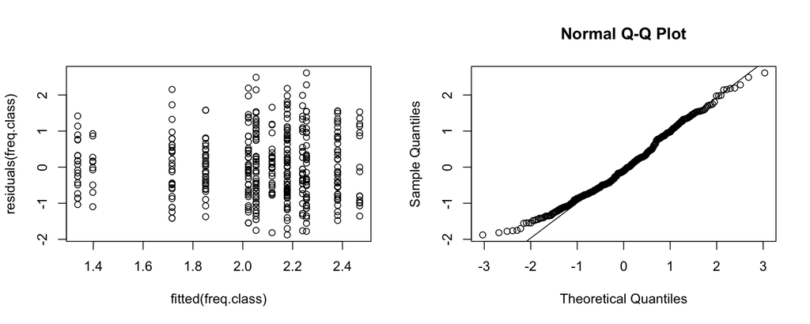

```r
# Log frequency, cluster:

par(mfrow = c(1, 2))
plot(fitted(freq.class), residuals(freq.class))
qqnorm(residuals(freq.class)); qqline(residuals(freq.class))
```

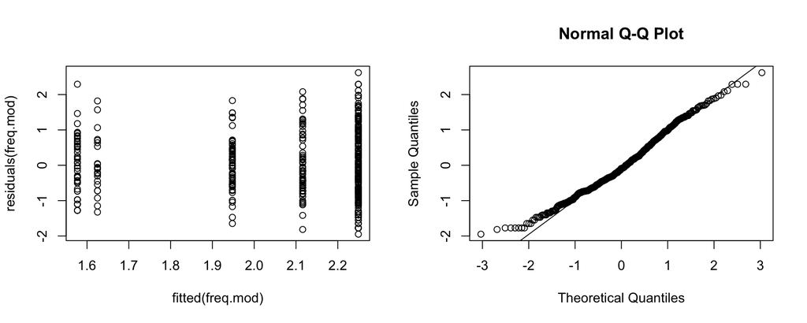

```r
# Log frequency, categorical:

par(mfrow = c(1, 2))
plot(fitted(freq.mod), residuals(freq.mod))
qqnorm(residuals(freq.mod)); qqline(residuals(freq.mod))
```

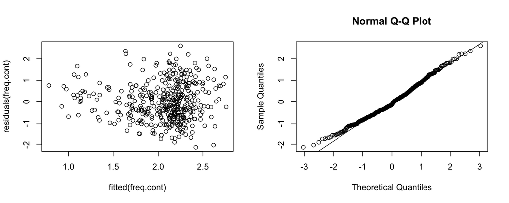

```r
# Log frequency, continuous:

par(mfrow = c(1, 2))
plot(fitted(freq.cont), residuals(freq.cont))
qqnorm(residuals(freq.cont)); qqline(residuals(freq.cont))
```

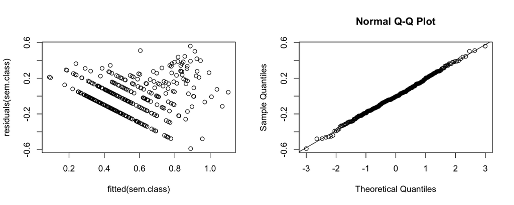

```r
# Semantic complexity, cluster:

par(mfrow = c(1, 2))
plot(fitted(sem.class), residuals(sem.class))
qqnorm(residuals(sem.class)); qqline(residuals(sem.class))
```

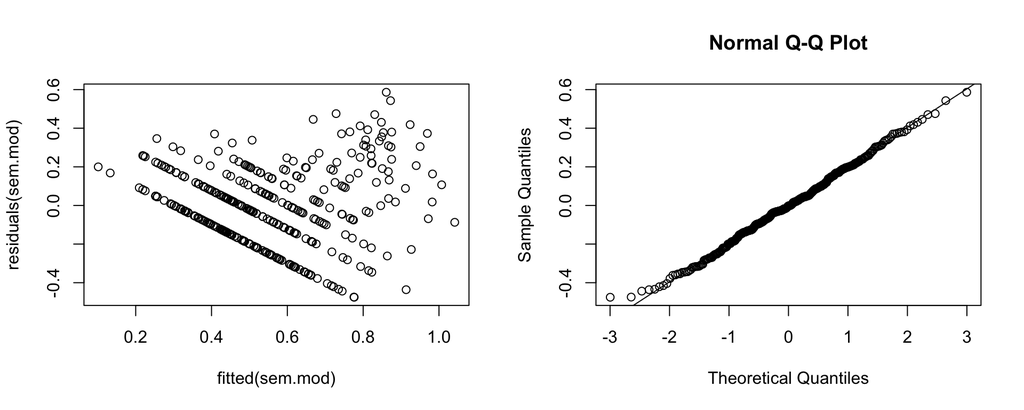

```r
# Semantic complexity, categorical:

par(mfrow = c(1, 2))
plot(fitted(sem.mod), residuals(sem.mod))
qqnorm(residuals(sem.mod)); qqline(residuals(sem.mod))
```

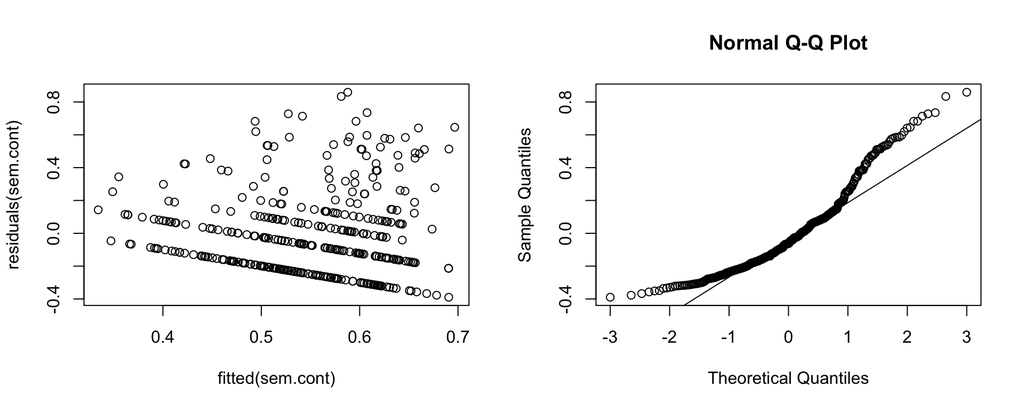

```r
# Semantic complexity, continuous:

par(mfrow = c(1, 2))
plot(fitted(sem.cont), residuals(sem.cont))
qqnorm(residuals(sem.cont)); qqline(residuals(sem.cont))
```

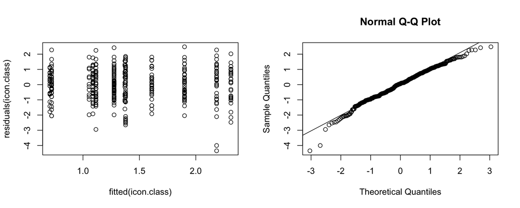

```r
# Iconicity, cluster:

par(mfrow = c(1, 2))
plot(fitted(icon.class), residuals(icon.class))
qqnorm(residuals(icon.class)); qqline(residuals(icon.class))
```

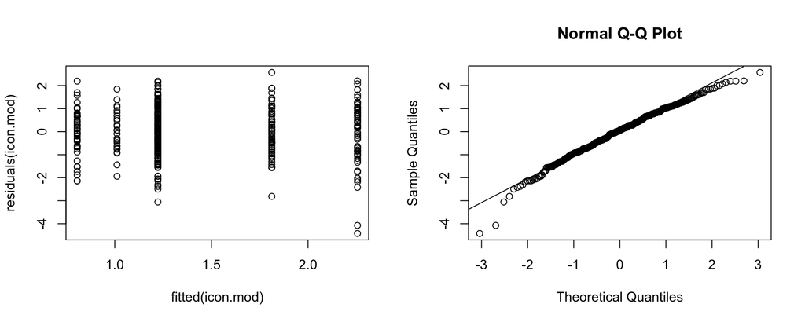

```r
# Iconicity, categorical:

par(mfrow = c(1, 2))
plot(fitted(icon.mod), residuals(icon.mod))
qqnorm(residuals(icon.mod)); qqline(residuals(icon.mod))
```

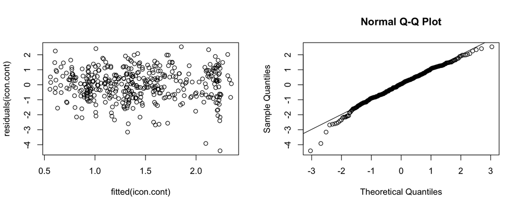

```r
# Iconicity, continuous:

par(mfrow = c(1, 2))
plot(fitted(icon.cont), residuals(icon.cont))
qqnorm(residuals(icon.cont)); qqline(residuals(icon.cont))
```

This completes the analyses presented in Chapter 15.